# Websites

ESS 3I: Webscraping and Data Management in R

Aug 2020

## Webscraping

If no API is available, we can scrape a website directory. Webscraping has a number of benefits and challenges compared to APIs:

**Webscraping Benefits**

- Any content that can be viewed on a webpage can be scraped. [Period](https://blog.hartleybrody.com/web-scraping/)
- No API needed
- No rate-limiting or authentication (usually)

**Webscraping Challenges**

- Rarely tailored for researchers
- Messy, unstructured, inconsistent
- Entirely site-dependent

#### Some Disclaimers

- Check a site's terms and conditions before scraping.
- Be nice - don't hammer the site's server. Review [these ethical webscraping tips](https://towardsdatascience.com/ethics-in-web-scraping-b96b18136f01)
- Sites change their layout all the time. Your scraper will break.

### What's a website?

A website is some combination of **code**base + **data**base that lives on a server.

When it gets to us (the "front end"), it's delivered to us as HTML + CSS stylesheets + javascript.

```html
"<!DOCTYPE html>\n<html lang=\"mul\" dir=\"ltr\">\n<head>\n<!-- Sysops:
Please do not edit the main template directly; update /temp and synchronise.
-->\n<meta charset=\"utf-8\">\n<title>Wikipedia</title>\n<!--[if lt IE 7]><meta
http-equiv=\"imagetoolbar\" content=\"no\"><![endif]-->\n<meta name=\"viewport\"
content=\"i"
```

Your browser turns that into a nice layout.

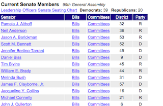

### HTML

The core of a website is **HTML** (Hyper Text Markup Language.) HTML defines the **structure** of a webpage using a series of **elements**. HTML elements tell the browser how to display the page by labeling pieces of content: "this is a heading", "this is a paragraph", "this is a link", etc.

```html
<!DOCTYPE html>
<html>
    <head>
        <title>Page title</title>
    </head>
    <body>
        <p>Hello world!</p>
    </body>
</html>
```

HTML elements can contain other elements:

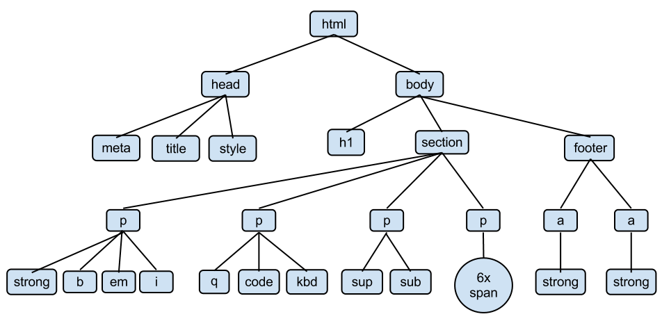

An HTML element is defined by a start tag, some content, and an end tag.

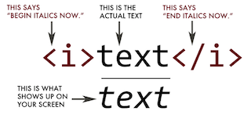

The HTML element is everything from the start tag to the end tag.

#### HTML: Tags

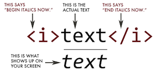

**Common HTML tags**

| Tag | Meaning |
| --- | --- |
| `<head>` | page header (metadata, etc |
| `<body>` | holds all of the content |
| `<p>` | regular text (paragraph) |
| `<h1>`,`<h2>`,`<h3>` | header text, levels 1, 2, 3 |
| `ol,`,`<ul>`,`<li>` | ordered list, unordered list, list item |
| `<a href="page.html">` | link to "page.html" |
| `<table>`,`<tr>`,`<td>` | table, table row, table item |
| `<div>`,`<span` | general containers |

#### HTML Attributes

- HTML elements can have attributes.
- Attributes provide additional information about an element.
- Attributes are always specified in the start tag.
- Attributes come in name/value pairs like: name="value"

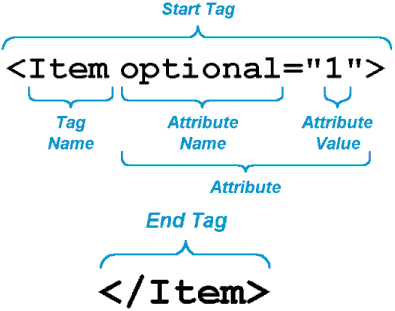

- Sometimes we can find the data we want just by using HTML tags or attributes (e.g, all the `<a>` tags)
- More often, this isn't enough: There might be 1000 `<a>` tags on a page. But maybe we want only the `<a>` tags *inside* of a `<p>` tag.
- Enter CSS...

### CSS

CSS stands for **Cascading Style Sheet**. CSS defines how HTML elements are to be displayed.

HTML came first. But it was only meant to define content, not format it. While HTML contains tags like `<font>` and `<color>`, this is a very inefficient way to develop a website. Some websites can easily contain 100+ individual pages, which with their own html code.

To solve this problem, CSS was created specifically to display content on a webpage. Now, one can change the look of an entire website just by changing one file.

Most web designers litter the HTML markup with tons of `class`es and `id`s to provide "hooks" for their CSS.

You can piggyback on these to jump to the parts of the markup that contain the data you need.

#### CSS Anatomy

- Selectors
  - Element selector: `p`
  - Class selector: `p class="blue"`
  - I.D. selector: `p id="blue"`
- Declarations
  - Selector: `p`
  - Property: `background-color`
  - Value: `yellow`
- Hooks

[figure not shown]

#### CSS + HTML

```html
<body>
    <table id="content">
        <tr class='name'>
            <td class='firstname'>
                Kurtis
            </td>
            <td class='lastname'>
                McCoy
            </td>
        </tr>
        <tr class='name'>
            <td class='firstname'>
                Leah
            </td>
            <td class='lastname'>
                Guerrero
            </td>
        </tr>
    </table>
</body>
```

#### Challenge 1

Find the CSS selectors for the following elements in the HTML above.

(Hint: There will be multiple solutions for each)

1. The entire table
2. The row containing "Kurtis McCoy"
3. Just the element containing first names

### Finding Elements with Selector Gadget

Selector Gadget is a browser plugin to help you find HTML elements. Install Selector Gadget on your browser by following [these instructions](https://selectorgadget.com/).

Once installed, run Selector Gadget and simply click on the type of information you want to select from the webpage. Once this is selected, you can then click the pieces of information you **don't** want to keep. Do this until only the pieces you want to keep remain highlighted, then copy the selector from the bottom pane.

Here's the basic strategy of webscraping:

1. Use Selector Gadget to see how your data is structured
2. Pay attention to HTML tags and CSS selectors
3. Pray that there is some kind of pattern
4. Use R and add-on modules like `RVest` to extract just that data.

#### Challenge 2

Go to http://rochelleterman.github.io/. Using Selector Gadget,

1. Find the CSS selector capturing all rows in the table.
2. Find the image source URL.
3. Find the HREF attribute of the link.